# act_report.pdf

## Report: act_report

- This basically communicates the insights and displays the visualization(s) produced from my wrangled data.

In this project, I worked with three datasets.

The first dataset was provided by Udacity which is a csv file named twitter_archive_enhanced.csv. It contains basic information about 2356 tweets.

The second dataset is a tsv file named image_prediction.tsv which was programmatically downloaded using python requests library. It contains 2075 predictions.

For the third dataset, I queried the twitter API using python Tweepy’s Library. This third dataset contains 2327 tweets in the file called "tweet_json_text".

During wrangling process, I found out 8 quality issues and 2 tidiness issues. I used various Pandas methods and functions to clean them up.

Below are some the insights from the data:

1. The distance between the 75th percentile to the maximum is quite large, this is so because some tweets had some outrageous rating
2. Most tweets had more favourites than retweet
3. The maximum dog rating is 1,776 and the minimum dog rating is 0.

# plot a scatter diagram showing the relationship between the retweets and favorites count.

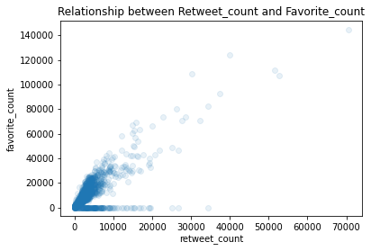